# Discussion 7 - Demo

Cameron Jones

Week of March 27

# Concept Review

### Expectation and Variance

Knowing a random variable follows a common distribution is useful because statisticians have derived shorter, more convenient formulas for the expectation and variance of these distributions.

For example, the general formula for the expectation (the average value) of a random variable is:

$$\mu = \mathbb{E}(X) = \sum x P(X=x)$$

However, when we know a variable follows the binomial distribution, this formula simplifies to:

$$\mu = \mathbb{E}(Binom(n, p)) = n*p$$

A similar result holds for the variance (a measure of the spread) of a random variable. The general formula is:

$$\sigma^2 = Var(X) = \sum (x - \mu)^2 P(X=x)$$

While the binomial simplified formula is:

$$\sigma^2 = Var(Binom(n,p)) = n*p*(1-p)$$

### In R: dbinom, pbinom, qbinom, and rbinom

Furthermore, knowing a random variable follows a common distribution allows for quick computation of probabilities through R commands.

The suite of commands `d<dist>`, `p<dist>`, `q<dist>`, and `r<dist>` work exactly the same for all the distributions R can handle; here is an abbreviation for the distribution’s name; e.g. ‘binom’ for ‘binomial’, ‘norm’ for ‘normal’, just ‘t’ for the t distribution, et cetera.

I provide binomial examples below, but these principles hold for any distribution.

##### dbinom

`dbinom(x, size, prob)` returns the probability of getting EXACTLY $x$ successes from $size$ trials, each with success probability $prob$.

e.g. What is the probability of getting EXACTLY 55 heads from 100 coin flips?

```r
dbinom(55, 100, 0.5)
```

```
## [1] 0.0484743
```

##### pbinom

`pbinom(q, size, prob)` gives us the probability of getting $q$ OR FEWER successes from $size$ trials with probability of success $prob$.

e.g. what is the probability I get 55 OR FEWER heads from 100 coin flips?

```r
pbinom(55, 100, 0.5)
```

```
## [1] 0.8643735
```

##### qbinom

`qbinom(p, size, prob)` tells us at what value of the random variable there is $p$% chance of getting an equal or lower value.

(It is the reverse of pbinom.)

e.g. There is a 95% chance of getting less than or equal to how many heads?

```r
qbinom(0.95, 100, 0.5)
```

```
## [1] 58
```

##### rbinom

`rbinom(n, size, prob)` is unrelated to probability generation. This command generates $n$ random values from $Binom(size, prob)$.

e.g. One ‘experiment’ consists of flipping a coin 5 times and counting the number of heads one obtains. Run this experiment 20 times.

```r
rbinom(20, 5, 0.5)
```

```
##  [1] 4 3 1 2 1 2 2 2 3 2 3 3 3 2 3 4 2 1 4 2
```

```r
# note; these values are not themselves coin flips! each value comes from flipping a coin 5 times and counting the heads.
```

### Summary

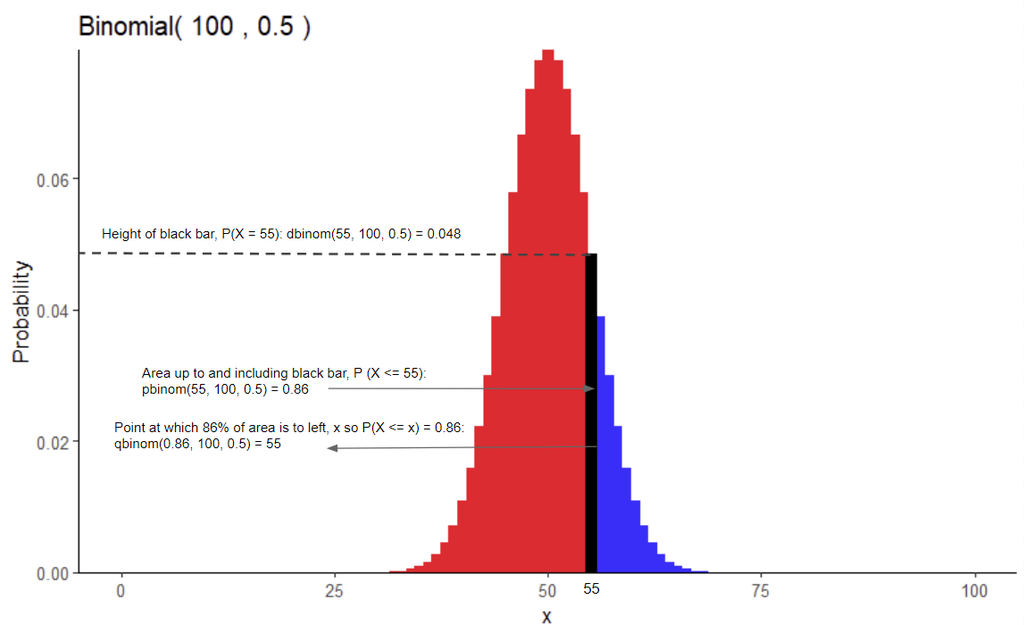

This image may not display if you do not have ProbabilityDemonstration.png saved next to this file.

Note; in this table (and all of statistics) the capital $X$ refers to a random variable, and the lowercase x refers to a number, usually specified by the user.

| Command | In | Out |
| --- | --- | --- |
| `d<dist>` | A value, x | $P(X = x)$ |
| `p<dist>` | A value, q | $P(X <= q)$ |
| `q<dist>` | A probability, p | $x$, such that $P(X <= x) = p$ |

### Extra Content: The Binomial Distribution Basics

(too much content to go over in discussion… but wanted to leave this available to students!)

**Recall: What is a random variable?** A random variable is a number which could take on a new value every time we run an experiment.

When we know certain things about the way a random variable is generated, we can assign probabilities to the different possible values that random variable might take on. The probabilities of the different values make up the **distribution** of the random variable.

One common example is the binomial distribution, which arises when our random variable is the number of “successes” from trials with:

- *Binary outcomes*: A single trial either fails or succeeds.
- *Independence*: Trials do not affect each other.
- *Number of trials fixed*: The number of trials is pre-determined.
- *Success probability fixed*: Each trial has the same probability of succeeding.

For example; I know that if I flip a coin, I have a 50% chance of getting heads and a 50% chance of getting tails. Flip a fair coin twice; let $X$ be the number of heads I get. Because $X$ is the number of successes of a fixed number of independent trials, we know that $X$ follows the *“binomial distribution”*. With this knowledge, we can calculate how likely each possible value of $X$ is. There is a 1/4 chance I’ll get 0 heads, 1/2 chance I’ll get 1 head, and a 1/4 chance I’ll get 2 heads.

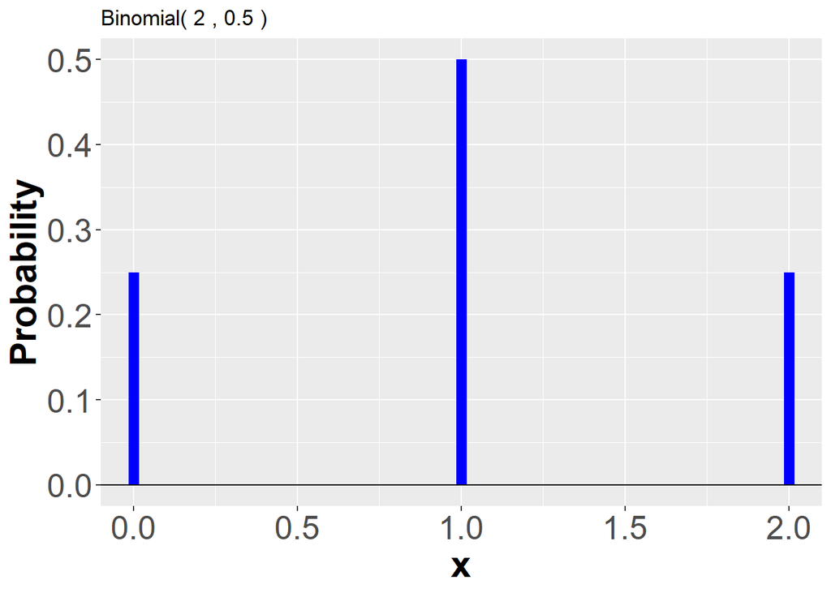

```r
gbinom(n=2, p=0.5, size=3) +
    theme(axis.text=element_text(size=20),
        axis.title=element_text(size=22,face="bold"))
```

These probabilities are easily computed by hand, but what if I flip a fair coin 100 times? Knowing it follows the binomial distribution allows us to quickly produce all of the probabilities to the values which $X$ can take on.

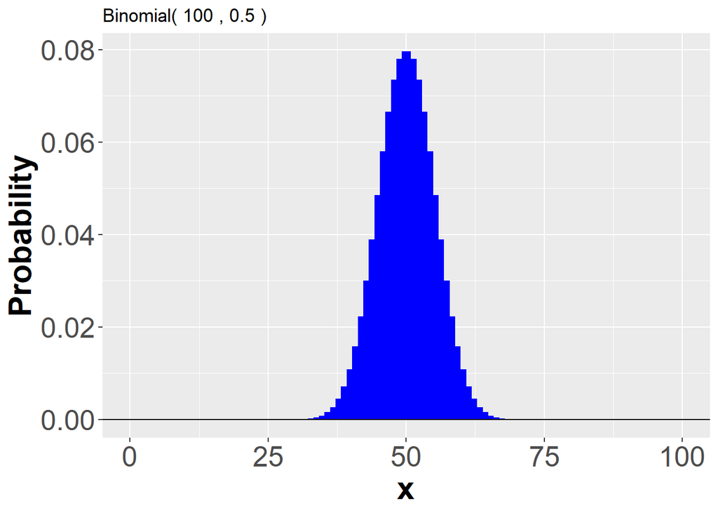

```r
gbinom(n=100, p=0.5, size=3) +
    theme(axis.text=element_text(size=20),
        axis.title=element_text(size=22,face="bold"))
```

Also, as above, knowing the variable follows the binomial distribution allows for quick calculation of its average, variance, and any probability you want.